# Final Project Report

Colin Arscott

12/13/2020

## Data Wrangling

The data did not come in a format that was usable for my purposes right off the bat. I needed to do significant data wrangling in order to make the data usable.

### CostOfLiving

The dataset called CostOfLiving has the following structure before data wrangling:

```r
CostOfLiving
```

| X | Saint.Petersburg..Russia | Istanbul..Turkey | Izmir..Turkey | Helsinki..Finland | Chisinau..Moldova | Milan..Italy | Cairo..Egypt | Banja.Luka..Bosnia.And.Herzegovina | Baku..Azerbaijan | Guadalajara..Mexico | Kathmandu..Nepal | Hanoi..Vietnam | Ho.Chi.Minh.City..Vietnam | Mexico.City..Mexico | Rome..Italy | Monterrey..Mexico | Yekaterinburg..Russia | Sarajevo..Bosnia.And.Herzegovina | Kharkiv..Ukraine | Kiev..Ukraine | Calgary..Canada | Tunis..Tunisia | Edmonton..Canada | Amsterdam..Netherlands | Belgrade..Serbia | Odessa..Ukraine | Paris..France | Eindhoven..Netherlands | Plovdiv..Bulgaria | … |
| --- | --- | --- | --- | --- | --- | --- | --- | --- | --- | --- | --- | --- | --- | --- | --- | --- | --- | --- | --- | --- | --- | --- | --- | --- | --- | --- | --- | --- | --- | --- |
| Meal, Inexpensive Restaurant | 7.34 | 4.58 | 3.06 | 12.00 | 4.67 | 15.00 | 3.38 | 3.58 | 5.27 | 5.25 | 1.99 | 1.94 | 1.94 | 4.77 | 15.00 | 5.75 | 5.88 | 3.57 | 4.50 | 5.63 | 13.75 | 1.92 | 13.75 | 15.00 | 5.39 | 5.65 | 15.00 | 15.00 | 5.10 | … |
| Meal for 2 People, Mid-range Restaurant, Three-course | 29.35 | 15.28 | 12.22 | 65.00 | 20.74 | 60.00 | 17.48 | 22.99 | 23.73 | 23.86 | 11.92 | 15.52 | 17.50 | 23.86 | 55.00 | 23.94 | 29.42 | 20.42 | 18.76 | 22.51 | 42.97 | 12.78 | 48.12 | 65.00 | 24.62 | 20.67 | 50.00 | 56.50 | 20.42 | … |
| McMeal at McDonalds (or Equivalent Combo Meal) | 4.40 | 3.82 | 3.06 | 8.00 | 4.15 | 8.00 | 4.51 | 3.58 | 4.22 | 4.25 | 5.56 | 3.88 | 3.87 | 4.77 | 8.00 | 4.31 | 4.12 | 4.08 | 3.75 | 3.75 | 6.87 | 3.19 | 6.53 | 8.00 | 5.09 | 3.67 | 8.70 | 8.00 | 4.59 | … |
| Domestic Beer (0.5 liter draught) | 2.20 | 3.06 | 2.29 | 6.50 | 1.04 | 5.00 | 1.69 | 1.02 | 0.84 | 1.43 | 2.38 | 0.78 | 0.78 | 1.91 | 5.00 | 1.68 | 1.47 | 1.79 | 0.88 | 1.13 | 4.81 | 1.60 | 4.12 | 5.00 | 1.70 | 0.94 | 7.00 | 5.00 | 1.28 | … |
| Imported Beer (0.33 liter bottle) | 2.20 | 3.06 | 2.75 | 6.75 | 1.43 | 5.00 | 2.82 | 1.53 | 2.11 | 2.39 | 3.18 | 1.55 | 1.36 | 2.86 | 4.00 | 2.39 | 2.94 | 1.79 | 1.29 | 1.80 | 5.50 | 1.60 | 4.12 | 4.00 | 1.95 | 1.20 | 6.00 | 3.00 | 1.53 | … |
| Coke/Pepsi (0.33 liter bottle) | 0.76 | 0.64 | 0.61 | 2.66 | 0.64 | 2.49 | 0.29 | 1.18 | 0.37 | 0.66 | 0.45 | 0.45 | 0.43 | 0.61 | 1.87 | 0.69 | 0.77 | 1.36 | 0.38 | 0.58 | 1.63 | 0.50 | 1.48 | 2.35 | 1.34 | 0.57 | 3.14 | 2.41 | 0.95 | … |
| Water (0.33 liter bottle) | 0.53 | 0.24 | 0.22 | 1.89 | 0.44 | 1.12 | 0.18 | 0.74 | 0.21 | 0.51 | 0.20 | 0.28 | 0.26 | 0.47 | 0.99 | 0.54 | 0.53 | 0.68 | 0.29 | 0.45 | 1.51 | 0.28 | 1.20 | 1.96 | 0.92 | 0.42 | 2.19 | 1.99 | 0.64 | … |
| Milk (regular), (1 liter) | 0.98 | 0.71 | 0.65 | 0.96 | 0.68 | 1.21 | 0.84 | 0.69 | 0.83 | 0.87 | 0.67 | 1.32 | 1.21 | 0.91 | 1.28 | 0.91 | 0.75 | 0.70 | 0.85 | 0.93 | 1.35 | 0.39 | 1.57 | 1.02 | 0.79 | 0.97 | 1.24 | 0.93 | 1.03 | … |
| Loaf of Fresh White Bread (500g) | 0.71 | 0.36 | 0.38 | 2.27 | 0.33 | 1.94 | 0.51 | 0.63 | 0.26 | 1.35 | 0.43 | 0.71 | 0.66 | 1.44 | 1.54 | 1.51 | 0.43 | 0.52 | 0.41 | 0.58 | 1.83 | 0.10 | 1.82 | 1.43 | 0.42 | 0.45 | 1.52 | 1.09 | 0.56 | … |
| Eggs (regular) (12) | 1.18 | 1.62 | 1.51 | 2.02 | 1.11 | 2.87 | 1.04 | 1.47 | 1.03 | 1.25 | 1.29 | 1.31 | 1.26 | 1.36 | 2.96 | 1.60 | 0.92 | 1.49 | 1.00 | 1.13 | 2.19 | 0.82 | 2.20 | 2.64 | 1.37 | 1.18 | 3.40 | 2.44 | 1.53 | … |

[output cut: 45 more lines]

This has a few problems that need to be sorted out. Firstly, there are way too many cities included here. I would like to narrow the scope to include only cities in the United States as Penn State students are most likely going to end up working and living somewhere in the United States after college.  
The first step will be to filter out all columns that are not located in America.

```r
WrangledCost <- CostOfLiving %>% select(X,contains("United.States")) %>% rename("TypeOfGood" = X)
WrangledCost
```

| TypeOfGood | Austin..TX..United.States | Boston..MA..United.States | Chicago..IL..United.States | Dallas..TX..United.States | Houston..TX..United.States | Las.Vegas..NV..United.States | Los.Angeles..CA..United.States | New.York..NY..United.States | Phoenix..AZ..United.States | Portland..OR..United.States | San.Diego..CA..United.States | San.Francisco..CA..United.States | Seattle..WA..United.States |
| --- | --- | --- | --- | --- | --- | --- | --- | --- | --- | --- | --- | --- | --- |
| Meal, Inexpensive Restaurant | 13.48 | 13.47 | 13.47 | 13.48 | 13.48 | 13.47 | 13.47 | 17.97 | 10.77 | 12.58 | 13.48 | 15.95 | 13.48 |
| Meal for 2 People, Mid-range Restaurant, Three-course | 44.92 | 62.85 | 53.87 | 44.92 | 53.91 | 53.87 | 58.36 | 76.37 | 53.87 | 44.92 | 53.91 | 71.88 | 62.89 |
| McMeal at McDonalds (or Equivalent Combo Meal) | 7.19 | 7.18 | 7.18 | 6.51 | 6.74 | 7.18 | 7.18 | 8.09 | 6.73 | 6.74 | 6.74 | 8.98 | 7.19 |
| Domestic Beer (0.5 liter draught) | 4.49 | 6.29 | 4.94 | 4.49 | 5.39 | 5.39 | 5.39 | 6.29 | 3.59 | 4.49 | 5.39 | 6.29 | 5.39 |
| Imported Beer (0.33 liter bottle) | 5.39 | 6.73 | 6.29 | 5.39 | 5.84 | 6.29 | 6.29 | 7.19 | 4.49 | 4.49 | 6.29 | 7.19 | 5.84 |
| Coke/Pepsi (0.33 liter bottle) | 1.87 | 1.75 | 1.75 | 1.69 | 1.81 | 1.45 | 2.03 | 1.85 | 1.53 | 1.78 | 1.74 | 2.26 | 1.97 |
| Water (0.33 liter bottle) | 1.37 | 1.53 | 1.52 | 1.42 | 1.59 | 1.06 | 1.59 | 1.59 | 1.07 | 1.35 | 1.39 | 1.72 | 1.52 |
| Milk (regular), (1 liter) | 0.75 | 0.78 | 0.70 | 0.64 | 0.68 | 0.70 | 0.87 | 1.04 | 0.51 | 0.78 | 0.88 | 0.98 | 0.77 |
| Loaf of Fresh White Bread (500g) | 2.40 | 2.62 | 2.54 | 2.20 | 2.03 | 1.81 | 2.99 | 3.33 | 2.18 | 2.83 | 3.27 | 3.12 | 2.76 |
| Eggs (regular) (12) | 2.24 | 2.34 | 2.05 | 1.85 | 1.92 | 1.64 | 2.91 | 3.28 | 1.85 | 2.62 | 3.20 | 2.82 | 2.40 |

[output cut: 45 more lines]

During this step, I also renamed the first column from a generic “X” to a more descriptive “Type of Good”. Now after this initial step, the data is already way easier to look at and compare between cities. The next step is to remove all the types of goods that I wont be focusing on. This dataset is very in depth and contains many goods, butr I will only be keeping the essentials.

```r
WrangledCost <- WrangledCost %>% filter(TypeOfGood == "Meal, Inexpensive Restaurant"|
                                        TypeOfGood == "Meal for 2 People, Mid-range Restaurant, Three-course"|
                                        TypeOfGood == "Milk (regular), (1 liter)"|
                                        TypeOfGood == "Volkswagen Golf"|
                                        TypeOfGood == "Apartment (1 bedroom) in City Centre"|
                                        TypeOfGood == "Apartment (1 bedroom) Outside of Centre"|
                                        TypeOfGood == "Utilities"|
                                        TypeOfGood == "Internet"|
                                        TypeOfGood == "Gasoline (1 liter)")
WrangledCost
```

| TypeOfGood | Austin..TX..United.States | Boston..MA..United.States | Chicago..IL..United.States | Dallas..TX..United.States | Houston..TX..United.States | Las.Vegas..NV..United.States | Los.Angeles..CA..United.States | New.York..NY..United.States | Phoenix..AZ..United.States | Portland..OR..United.States | San.Diego..CA..United.States | San.Francisco..CA..United.States | Seattle..WA..United.States |
| --- | --- | --- | --- | --- | --- | --- | --- | --- | --- | --- | --- | --- | --- |
| Meal, Inexpensive Restaurant | 13.48 | 13.47 | 13.47 | 13.48 | 13.48 | 13.47 | 13.47 | 17.97 | 10.77 | 12.58 | 13.48 | 15.95 | 13.48 |
| Meal for 2 People, Mid-range Restaurant, Three-course | 44.92 | 62.85 | 53.87 | 44.92 | 53.91 | 53.87 | 58.36 | 76.37 | 53.87 | 44.92 | 53.91 | 71.88 | 62.89 |
| Milk (regular), (1 liter) | 0.75 | 0.78 | 0.70 | 0.64 | 0.68 | 0.70 | 0.87 | 1.04 | 0.51 | 0.78 | 0.88 | 0.98 | 0.77 |
| Gasoline (1 liter) | 0.56 | 0.66 | 0.74 | 0.56 | 0.57 | 0.76 | 0.94 | 0.71 | 0.70 | 0.77 | 0.92 | 0.95 | 0.84 |
| Volkswagen Golf | 19627.40 | 19789.80 | 19614.71 | 17071.22 | 20170.99 | 18856.43 | 19753.89 | 19627.40 | 19156.78 | 21563.64 | 20665.15 | 19802.61 | 22462.12 |
| Apartment (1 bedroom) in City Centre | 1581.66 | 2275.95 | 1702.25 | 1322.45 | 1258.81 | 992.86 | 1980.11 | 2854.26 | 1092.25 | 1399.80 | 1816.10 | 3131.06 | 1919.17 |
| Apartment (1 bedroom) Outside of Centre | 995.90 | 1716.68 | 1100.17 | 961.01 | 859.49 | 874.56 | 1564.78 | 1788.76 | 824.80 | 1045.69 | 1479.24 | 2527.11 | 1450.04 |
| Utilities | 124.12 | 119.59 | 117.08 | 139.51 | 122.34 | 138.51 | 111.99 | 116.65 | 161.50 | 150.98 | 123.99 | 127.73 | 144.15 |
| Internet | 55.38 | 61.70 | 57.23 | 59.67 | 54.13 | 64.64 | 55.74 | 55.18 | 67.23 | 60.86 | 56.97 | 60.00 | 58.46 |

Now that the table is limited to a few specific goods, it is easier to visualize the key differences between the cities. The next thing I want to do is to add a new column that will contain the average cost of that good across all cities.

```r
WrangledCost <- WrangledCost %>% mutate(Average = round(rowMeans(WrangledCost[,-1]),digits = 2))
WrangledCost
```

| TypeOfGood | Austin..TX..United.States | Boston..MA..United.States | Chicago..IL..United.States | Dallas..TX..United.States | Houston..TX..United.States | Las.Vegas..NV..United.States | Los.Angeles..CA..United.States | New.York..NY..United.States | Phoenix..AZ..United.States | Portland..OR..United.States | San.Diego..CA..United.States | San.Francisco..CA..United.States | Seattle..WA..United.States | Average |
| --- | --- | --- | --- | --- | --- | --- | --- | --- | --- | --- | --- | --- | --- | --- |
| Meal, Inexpensive Restaurant | 13.48 | 13.47 | 13.47 | 13.48 | 13.48 | 13.47 | 13.47 | 17.97 | 10.77 | 12.58 | 13.48 | 15.95 | 13.48 | 13.73 |
| Meal for 2 People, Mid-range Restaurant, Three-course | 44.92 | 62.85 | 53.87 | 44.92 | 53.91 | 53.87 | 58.36 | 76.37 | 53.87 | 44.92 | 53.91 | 71.88 | 62.89 | 56.66 |
| Milk (regular), (1 liter) | 0.75 | 0.78 | 0.70 | 0.64 | 0.68 | 0.70 | 0.87 | 1.04 | 0.51 | 0.78 | 0.88 | 0.98 | 0.77 | 0.78 |
| Gasoline (1 liter) | 0.56 | 0.66 | 0.74 | 0.56 | 0.57 | 0.76 | 0.94 | 0.71 | 0.70 | 0.77 | 0.92 | 0.95 | 0.84 | 0.74 |
| Volkswagen Golf | 19627.40 | 19789.80 | 19614.71 | 17071.22 | 20170.99 | 18856.43 | 19753.89 | 19627.40 | 19156.78 | 21563.64 | 20665.15 | 19802.61 | 22462.12 | 19858.63 |
| Apartment (1 bedroom) in City Centre | 1581.66 | 2275.95 | 1702.25 | 1322.45 | 1258.81 | 992.86 | 1980.11 | 2854.26 | 1092.25 | 1399.80 | 1816.10 | 3131.06 | 1919.17 | 1794.36 |
| Apartment (1 bedroom) Outside of Centre | 995.90 | 1716.68 | 1100.17 | 961.01 | 859.49 | 874.56 | 1564.78 | 1788.76 | 824.80 | 1045.69 | 1479.24 | 2527.11 | 1450.04 | 1322.17 |
| Utilities | 124.12 | 119.59 | 117.08 | 139.51 | 122.34 | 138.51 | 111.99 | 116.65 | 161.50 | 150.98 | 123.99 | 127.73 | 144.15 | 130.63 |
| Internet | 55.38 | 61.70 | 57.23 | 59.67 | 54.13 | 64.64 | 55.74 | 55.18 | 67.23 | 60.86 | 56.97 | 60.00 | 58.46 | 59.01 |

The final piece of data wrangling I would like to do to this dataset is to replace all the periods in the column titles with using regular expressions. I will be using my custom function ReplaceWithSpace to accomplish this.

```r
#This function takes a dataframe(DataFrame) and a symbol(s) as parameters. It returns a copy of the DataFrame with each instance of s in the column names replaced with a space. Note, Escape characters are required if s uses special characters
ReplaceWithSpace <- function(DataFrame,s){
  tempFrame <- DataFrame
  oldNames <- colnames(tempFrame)
  fixedNames <- gsub(pattern = s,replacement = " ",oldNames)
  colnames(tempFrame) <- fixedNames
  return(tempFrame)
}
WrangledCost <- ReplaceWithSpace(WrangledCost,"\\.")
WrangledCost
```

| TypeOfGood | Austin TX United States | Boston MA United States | Chicago IL United States | Dallas TX United States | Houston TX United States | Las Vegas NV United States | Los Angeles CA United States | New York NY United States | Phoenix AZ United States | Portland OR United States | San Diego CA United States | San Francisco CA United States | Seattle WA United States | Average |
| --- | --- | --- | --- | --- | --- | --- | --- | --- | --- | --- | --- | --- | --- | --- |
| Meal, Inexpensive Restaurant | 13.48 | 13.47 | 13.47 | 13.48 | 13.48 | 13.47 | 13.47 | 17.97 | 10.77 | 12.58 | 13.48 | 15.95 | 13.48 | 13.73 |
| Meal for 2 People, Mid-range Restaurant, Three-course | 44.92 | 62.85 | 53.87 | 44.92 | 53.91 | 53.87 | 58.36 | 76.37 | 53.87 | 44.92 | 53.91 | 71.88 | 62.89 | 56.66 |
| Milk (regular), (1 liter) | 0.75 | 0.78 | 0.70 | 0.64 | 0.68 | 0.70 | 0.87 | 1.04 | 0.51 | 0.78 | 0.88 | 0.98 | 0.77 | 0.78 |
| Gasoline (1 liter) | 0.56 | 0.66 | 0.74 | 0.56 | 0.57 | 0.76 | 0.94 | 0.71 | 0.70 | 0.77 | 0.92 | 0.95 | 0.84 | 0.74 |
| Volkswagen Golf | 19627.40 | 19789.80 | 19614.71 | 17071.22 | 20170.99 | 18856.43 | 19753.89 | 19627.40 | 19156.78 | 21563.64 | 20665.15 | 19802.61 | 22462.12 | 19858.63 |
| Apartment (1 bedroom) in City Centre | 1581.66 | 2275.95 | 1702.25 | 1322.45 | 1258.81 | 992.86 | 1980.11 | 2854.26 | 1092.25 | 1399.80 | 1816.10 | 3131.06 | 1919.17 | 1794.36 |
| Apartment (1 bedroom) Outside of Centre | 995.90 | 1716.68 | 1100.17 | 961.01 | 859.49 | 874.56 | 1564.78 | 1788.76 | 824.80 | 1045.69 | 1479.24 | 2527.11 | 1450.04 | 1322.17 |
| Utilities | 124.12 | 119.59 | 117.08 | 139.51 | 122.34 | 138.51 | 111.99 | 116.65 | 161.50 | 150.98 | 123.99 | 127.73 | 144.15 | 130.63 |
| Internet | 55.38 | 61.70 | 57.23 | 59.67 | 54.13 | 64.64 | 55.74 | 55.18 | 67.23 | 60.86 | 56.97 | 60.00 | 58.46 | 59.01 |

In order to make this data Glyph ready, I need to transpose the graph so that the rows are switched with the columns

```r
transposeCost <- data.frame(t(WrangledCost[-1])) #Scrape all but the first row
colnames(transposeCost) <- WrangledCost[,1]
transposeCost <- tibble::rownames_to_column(transposeCost,"City") #Create a new column called City containing city names
transposeCost
```

| City | Meal, Inexpensive Restaurant | Meal for 2 People, Mid-range Restaurant, Three-course | Milk (regular), (1 liter) | Gasoline (1 liter) | Volkswagen Golf | Apartment (1 bedroom) in City Centre | Apartment (1 bedroom) Outside of Centre | Utilities | Internet |
| --- | --- | --- | --- | --- | --- | --- | --- | --- | --- |
| Austin TX United States | 13.48 | 44.92 | 0.75 | 0.56 | 19627.40 | 1581.66 | 995.90 | 124.12 | 55.38 |
| Boston MA United States | 13.47 | 62.85 | 0.78 | 0.66 | 19789.80 | 2275.95 | 1716.68 | 119.59 | 61.70 |
| Chicago IL United States | 13.47 | 53.87 | 0.70 | 0.74 | 19614.71 | 1702.25 | 1100.17 | 117.08 | 57.23 |
| Dallas TX United States | 13.48 | 44.92 | 0.64 | 0.56 | 17071.22 | 1322.45 | 961.01 | 139.51 | 59.67 |
| Houston TX United States | 13.48 | 53.91 | 0.68 | 0.57 | 20170.99 | 1258.81 | 859.49 | 122.34 | 54.13 |
| Las Vegas NV United States | 13.47 | 53.87 | 0.70 | 0.76 | 18856.43 | 992.86 | 874.56 | 138.51 | 64.64 |
| Los Angeles CA United States | 13.47 | 58.36 | 0.87 | 0.94 | 19753.89 | 1980.11 | 1564.78 | 111.99 | 55.74 |
| New York NY United States | 17.97 | 76.37 | 1.04 | 0.71 | 19627.40 | 2854.26 | 1788.76 | 116.65 | 55.18 |
| Phoenix AZ United States | 10.77 | 53.87 | 0.51 | 0.70 | 19156.78 | 1092.25 | 824.80 | 161.50 | 67.23 |
| Portland OR United States | 12.58 | 44.92 | 0.78 | 0.77 | 21563.64 | 1399.80 | 1045.69 | 150.98 | 60.86 |

[output cut: 4 more lines]

### PayByDegree

This dataset does not need as much wrangling done to it as CostOfLiving. That being said, There are a few dollar signs and commas that need to be removed before data wrangling can begin. I also would like to fix the titles using my ReplaceWithSpace function.

```r
#First replace all the periods with spaces
WrangledPay <- ReplaceWithSpace(PayByDegree,"\\.")

#Then remove the currency symbol from the data
WrangledPay <- WrangledPay %>%
                mutate(`Starting Median Salary` = gsub(pattern = '[$,]', replacement = '', `Starting Median Salary`),
                       `Mid Career Median Salary` = gsub(pattern = '[$,]', replacement = '', `Mid Career Median Salary`),
                       `Mid Career 10th Percentile Salary` = gsub(pattern = '[$,]', replacement = '', `Mid Career 10th Percentile Salary`),
                       `Mid Career 25th Percentile Salary` = gsub(pattern = '[$,]', replacement = '', `Mid Career 25th Percentile Salary`),
                       `Mid Career 75th Percentile Salary` = gsub(pattern = '[$,]', replacement = '', `Mid Career 75th Percentile Salary`),
                       `Mid Career 90th Percentile Salary` = gsub(pattern = '[$,]', replacement = '', `Mid Career 90th Percentile Salary`))
WrangledPay
```

| Undergraduate Major | Starting Median Salary | Mid Career Median Salary | Percent change from Starting to Mid Career Salary | Mid Career 10th Percentile Salary | Mid Career 25th Percentile Salary | Mid Career 75th Percentile Salary | Mid Career 90th Percentile Salary |
| --- | --- | --- | --- | --- | --- | --- | --- |
| Accounting | 46000.00 | 77100.00 | 67.6 | 42200.00 | 56100.00 | 108000.00 | 152000.00 |
| Aerospace Engineering | 57700.00 | 101000.00 | 75.0 | 64300.00 | 82100.00 | 127000.00 | 161000.00 |
| Agriculture | 42600.00 | 71900.00 | 68.8 | 36300.00 | 52100.00 | 96300.00 | 150000.00 |
| Anthropology | 36800.00 | 61500.00 | 67.1 | 33800.00 | 45500.00 | 89300.00 | 138000.00 |
| Architecture | 41600.00 | 76800.00 | 84.6 | 50600.00 | 62200.00 | 97000.00 | 136000.00 |
| Art History | 35800.00 | 64900.00 | 81.3 | 28800.00 | 42200.00 | 87400.00 | 125000.00 |
| Biology | 38800.00 | 64800.00 | 67.0 | 36900.00 | 47400.00 | 94500.00 | 135000.00 |
| Business Management | 43000.00 | 72100.00 | 67.7 | 38800.00 | 51500.00 | 102000.00 | 147000.00 |
| Chemical Engineering | 63200.00 | 107000.00 | 69.3 | 71900.00 | 87300.00 | 143000.00 | 194000.00 |
| Chemistry | 42600.00 | 79900.00 | 87.6 | 45300.00 | 60700.00 | 108000.00 | 148000.00 |

[output cut: 40 more lines]

After removing all the unnecessary symbols, this dataset is looks like its in pretty good shape. The last bit of data wrangling I need to do is convert all the money values from strings to doubles. I need to do this because I cant do math operations on strings

```r
WrangledPay$`Starting Median Salary` <- as.double(WrangledPay$`Starting Median Salary`)
WrangledPay$`Mid Career Median Salary` <- as.double(WrangledPay$`Mid Career Median Salary`)
WrangledPay$`Mid Career 10th Percentile Salary` <- as.double(WrangledPay$`Mid Career 10th Percentile Salary`)
WrangledPay$`Mid Career 25th Percentile Salary` <- as.double(WrangledPay$`Mid Career 25th Percentile Salary`)
WrangledPay$`Mid Career 75th Percentile Salary` <- as.double(WrangledPay$`Mid Career 75th Percentile Salary`)
WrangledPay$`Mid Career 90th Percentile Salary` <- as.double(WrangledPay$`Mid Career 90th Percentile Salary`)
WrangledPay
```

| Undergraduate Major | Starting Median Salary | Mid Career Median Salary | Percent change from Starting to Mid Career Salary | Mid Career 10th Percentile Salary | Mid Career 25th Percentile Salary | Mid Career 75th Percentile Salary | Mid Career 90th Percentile Salary |
| --- | --- | --- | --- | --- | --- | --- | --- |
| Accounting | 46000 | 77100 | 67.6 | 42200 | 56100 | 108000 | 152000 |
| Aerospace Engineering | 57700 | 101000 | 75.0 | 64300 | 82100 | 127000 | 161000 |
| Agriculture | 42600 | 71900 | 68.8 | 36300 | 52100 | 96300 | 150000 |
| Anthropology | 36800 | 61500 | 67.1 | 33800 | 45500 | 89300 | 138000 |
| Architecture | 41600 | 76800 | 84.6 | 50600 | 62200 | 97000 | 136000 |
| Art History | 35800 | 64900 | 81.3 | 28800 | 42200 | 87400 | 125000 |
| Biology | 38800 | 64800 | 67.0 | 36900 | 47400 | 94500 | 135000 |
| Business Management | 43000 | 72100 | 67.7 | 38800 | 51500 | 102000 | 147000 |
| Chemical Engineering | 63200 | 107000 | 69.3 | 71900 | 87300 | 143000 | 194000 |
| Chemistry | 42600 | 79900 | 87.6 | 45300 | 60700 | 108000 | 148000 |

[output cut: 40 more lines]

Now all the values that should be doubles have been converted to doubles. The final bit of data wrangling I want to do on this data is calculate the Mean starting salary over all majors.

```r
count = 0
total = 0
#loop over each value in Starting Median Salary
for (i in WrangledPay$`Starting Median Salary`){
  total <- total + i #add this value to the total
  count <- count + 1 #keep track of each item
}
allDegreeMean <- total/count #calculate mean
print(allDegreeMean)
```

```
[1] 44310
```

That is all the data wrangling that needed to be done, now on to Data Visualization.

## Data Visualization

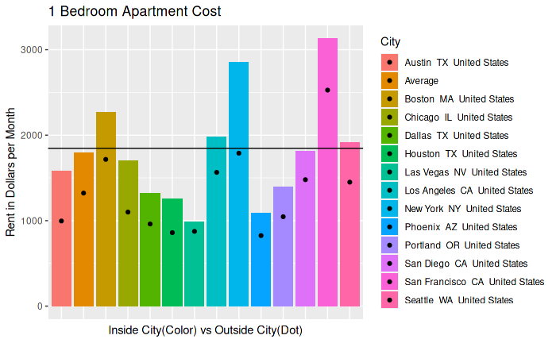

```r
transposeCost %>% ggplot(aes(x = City))+
      geom_bar(stat = "identity",aes(fill = City, y = `Apartment (1 bedroom) in City Centre`)) +
      geom_point(stat = "identity",aes(x = City, y = `Apartment (1 bedroom) Outside of Centre`  ,fill = City)) +
      xlab("Inside City(Color) vs Outside City(Dot)") +
      ylab("Rent in Dollars per Month") +
      ggtitle("1 Bedroom Apartment Cost") +
      geom_abline(slope = 0, intercept = allDegreeMean/24) +
      theme(axis.text.x = element_blank(), axis.ticks.x = element_blank())
```

In order to find out which city is the best city to live in post graduation, the most important factor is rent. It is generally recommended that rent should take up no more than half for your income. The horizontal line on the above graph is set to the value of half the average monthly income of college graduates. Any city that falls above the line takes up more than half of the average recent graduate’s monthly income. The colored bar represents the price of an apartment inside the city center, while the black dot represents the price of an apartment outside of the city center. From this graph we can draw the conclusion that on a city by city basis it is always more economical to live outside of the city center when given the option. The city with the lowest rate for a city center apartment is Las Vegas NV. The overall lowest rent price is for an apartment outside the city center in Phoenix AZ.

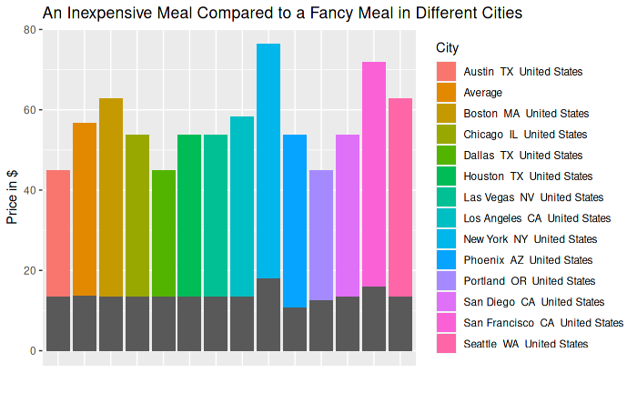

```r
transposeCost %>% ggplot(aes(x = City)) +
                  geom_bar(stat = 'identity', aes(y = `Meal for 2 People, Mid-range Restaurant, Three-course`,fill = City))+
                  geom_bar(aes(y  = `Meal, Inexpensive Restaurant`),stat = "identity") +
                  ylab("Price in $") +
                  xlab("") +
                  ggtitle("An Inexpensive Meal Compared to a Fancy Meal in Different Cities") +
                  theme(axis.text.x = element_blank(), axis.ticks.x = element_blank())
```

The Graph above shows that there is not a significant difference in the price of inexpensive meals in different cities. The difference in fancy meal prices is more significant. It needs to be said that a fancy meal is defined as a three course meal for two. One aspect of this graph that surprised me was that there does not appear to be a correlation between apartment price and fancy meal price. Two of the least expensive cities for rent, Las Vegas and Phoenix, are both very close to average price when it comes to food. Another interesting aspect of this graph is that the variation city to city is not as large as with rent. From this I can conclude that the price of prepared meals should not be a major factor in deciding where to live as they are pretty similar in cities all over the country.

## Conclusion

After looking at the data visualized by these graphs I was able to gain a greater understanding of the economic differences in cities across the United States. The differences in food prices were a lot lower than I expected. I also expected there to be more than one factor that would decide where the best place for a recent college graduate to live is. Despite my expectations, I was able to tell after looking at the data that apartment location relative to downtown, and by extension its monthly rent are the primary factors. When it comes to cities that new graduates should not choose to live in, 2 cities had monthly rent payments close to 50% of the average monthly income regardless of distance from the city center. These two cities are New York and San Francisco. Unless you are earning a salary well above the national average, these cities should be avoided. As for cities that have exceptionally low rent, two outperformed the rest. Phoenix had the overall lowest rent as long as you are able to live outside of the city center. But if you need to live downtown, Las Vegas has the least expensive apartments that are close to the city center. The remaining cities are all good options as they all have at least one option that is below the 50% monthly income threshold.